# Time Series model fitting of Boston Weather Data

Vivek Vikram Magadi

April 13, 2018

## Reading Data

The dataset that we have considered to work on is the Boston Weather dataset from July 2012 - August 2015. The dataset contains 5 different variables: 1. Temperature 2. Dewpoint 3. Humidity 4. Wind 5. Precipitation

As we shall see in the later part of the project, the precipitation variable shall not be considered as it is white noise.

Our data contains 1157 observations and 5 variables. Each observation is recorded on a daily basis.

Hypothesis : Our hypothesis is to forecast values of each variable. We have built two sets of models for comparison purposes. In the first set of models we model each variable as a univariate time series using ARIMA/SARIMA. In the second set of models we model a Vector Auto-Regressive model on all 4 variables. Then we compare to see if the Vector Auto-Regressive model gave us a better fit or did the Arima/Sarima models give us a better fit.

```
## Classes 'tbl_df', 'tbl' and 'data.frame':    1157 obs. of  8 variables:
##  $ precipitation: num  1 0 0 0.49 0 0 0 0 0 0 ...
##  $ day          : int  1 2 3 4 5 6 7 8 9 10 ...
##  $ month        : int  8 8 8 8 8 8 8 8 8 8 ...
##  $ year         : int  2015 2015 2015 2015 2015 2015 2015 2015 2015 2015 ...
##  $ temperature  : int  79 78 79 78 75 74 69 69 68 73 ...
##  $ dewpoint     : int  58 54 64 66 57 53 57 57 59 59 ...
##  $ humidity     : int  50 52 67 68 58 51 70 68 80 67 ...
##  $ wind         : int  10 11 13 9 11 9 8 6 9 10 ...
##  - attr(*, "spec")=List of 2
##   ..$ cols   :List of 8
##   .. ..$ precipitation: list()
##   .. .. ..- attr(*, "class")= chr  "collector_double" "collector"
##   .. ..$ day          : list()
##   .. .. ..- attr(*, "class")= chr  "collector_integer" "collector"
##   .. ..$ month        : list()
##   .. .. ..- attr(*, "class")= chr  "collector_integer" "collector"
##   .. ..$ year         : list()
##   .. .. ..- attr(*, "class")= chr  "collector_integer" "collector"
##   .. ..$ temperature  : list()
##   .. .. ..- attr(*, "class")= chr  "collector_integer" "collector"
##   .. ..$ dewpoint     : list()
##   .. .. ..- attr(*, "class")= chr  "collector_integer" "collector"
##   .. ..$ humidity     : list()
##   .. .. ..- attr(*, "class")= chr  "collector_integer" "collector"
##   .. ..$ wind         : list()
##   .. .. ..- attr(*, "class")= chr  "collector_integer" "collector"
##   ..$ default: list()
##   .. ..- attr(*, "class")= chr  "collector_guess" "collector"
##   ..- attr(*, "class")= chr "col_spec"
```

The timestamp was split into day, month and year variables starting from August 2015 to July 2012. we shall club them into a single variable and then reverse the order of the observations.

## Mean Difference

First we subtract the mean from all the variables to center them on the X axis.

## Plotting all the time series

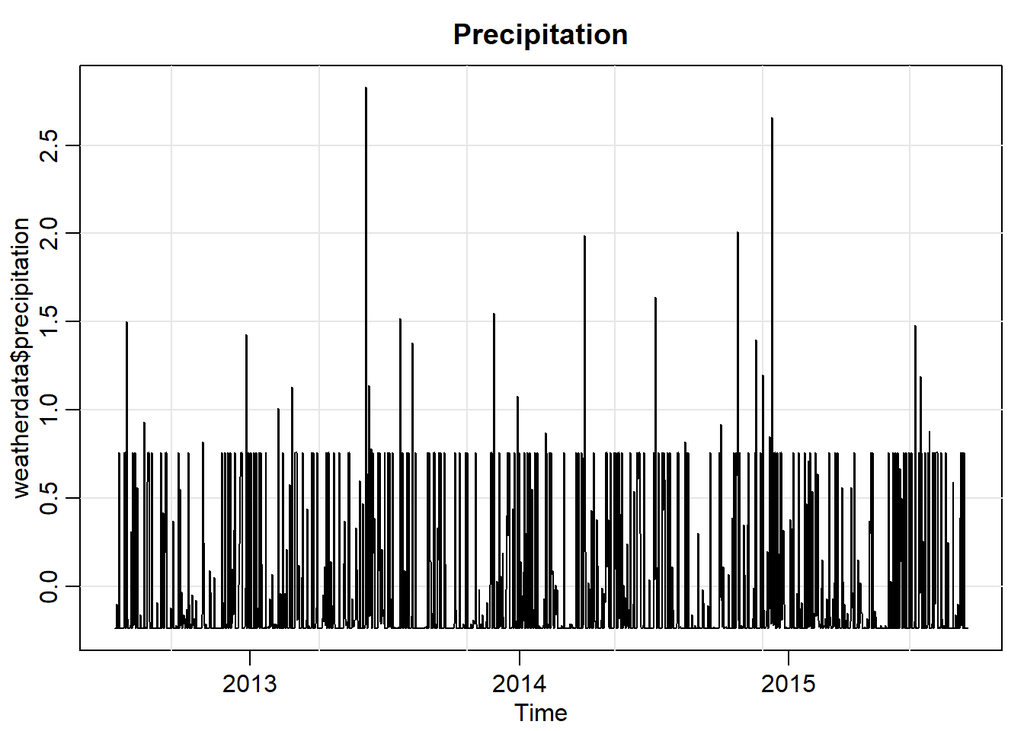

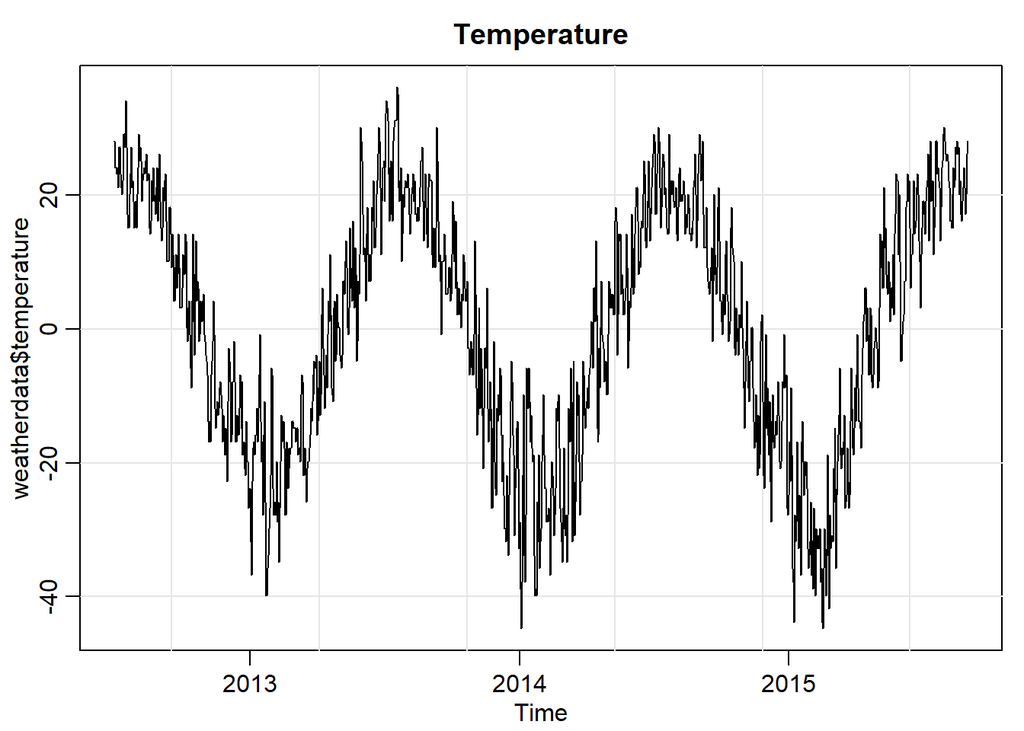

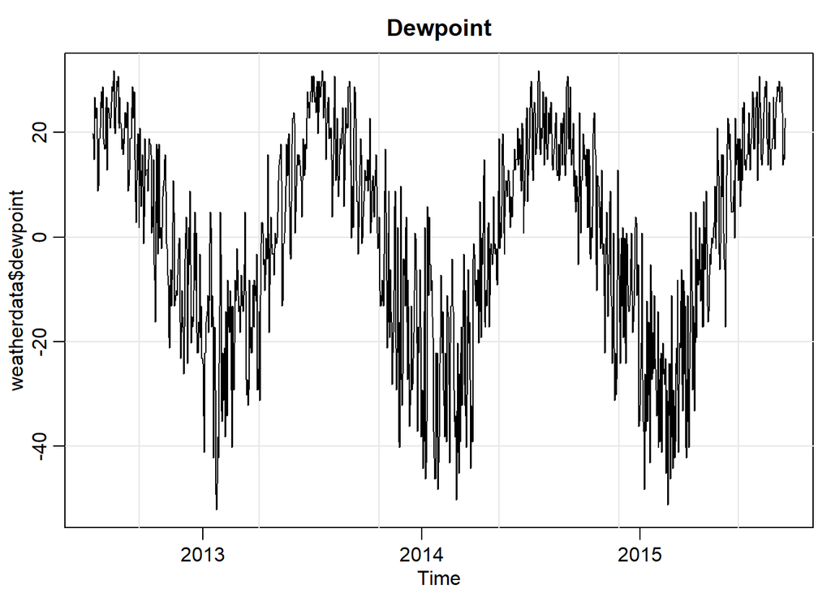

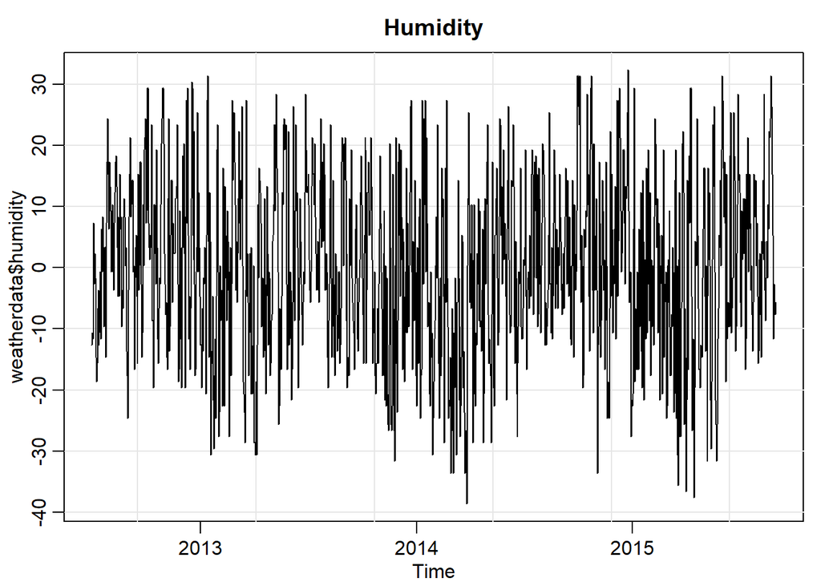

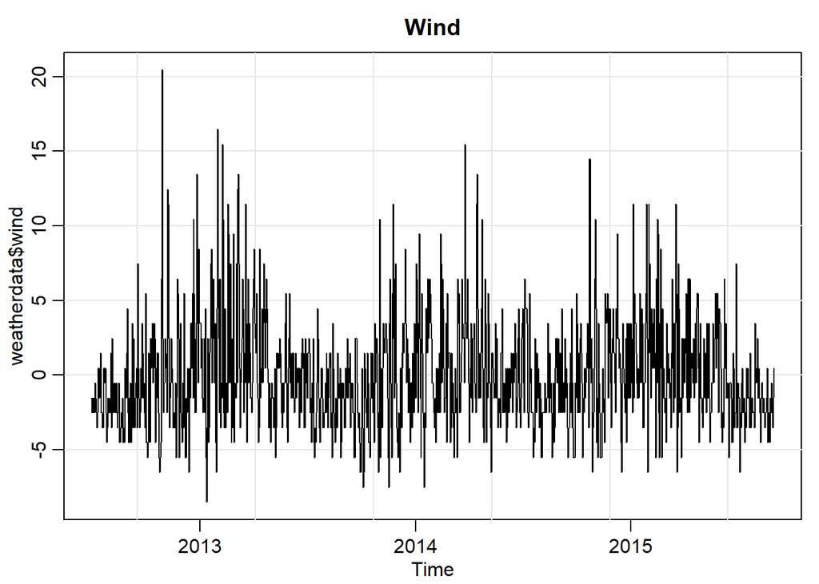

From the above Time Series plots we can see that precipitation almost looks like white noise; Temperature and Dewpoint have seasonal patterns ( looks like a yearly pattern).

## Decomposing Time Series plots

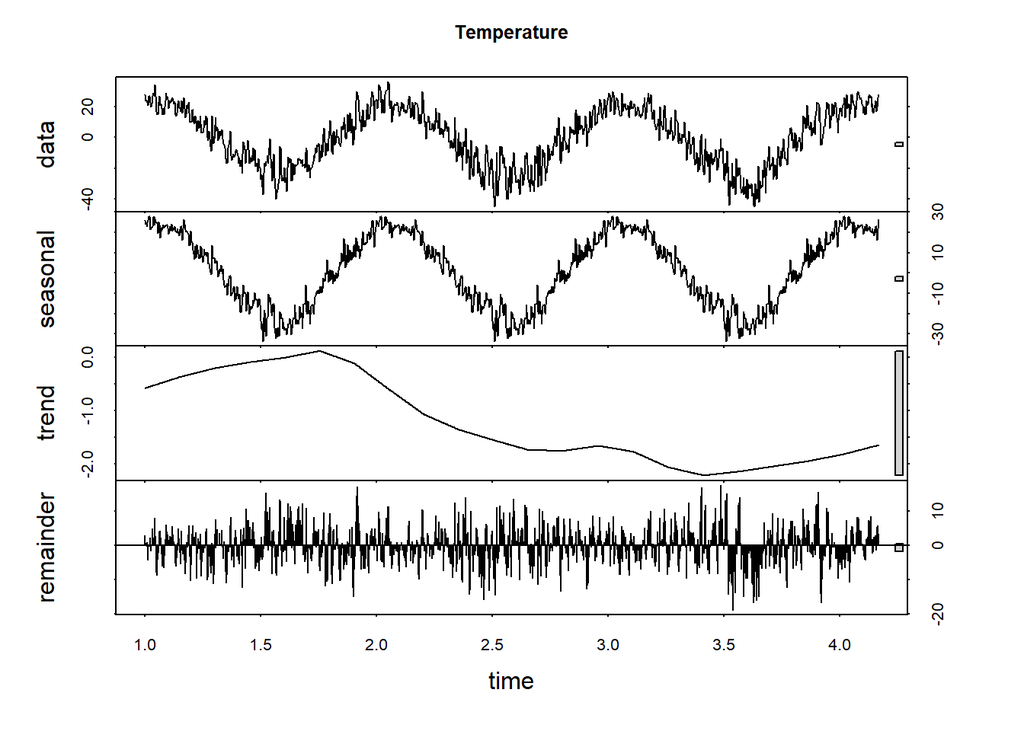

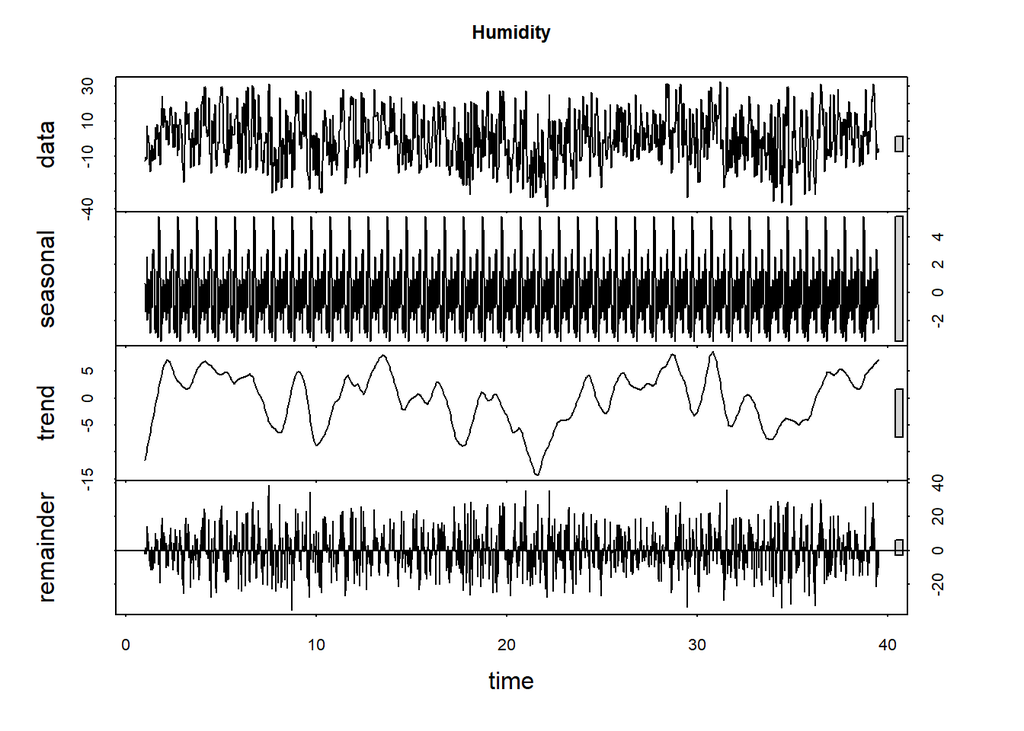

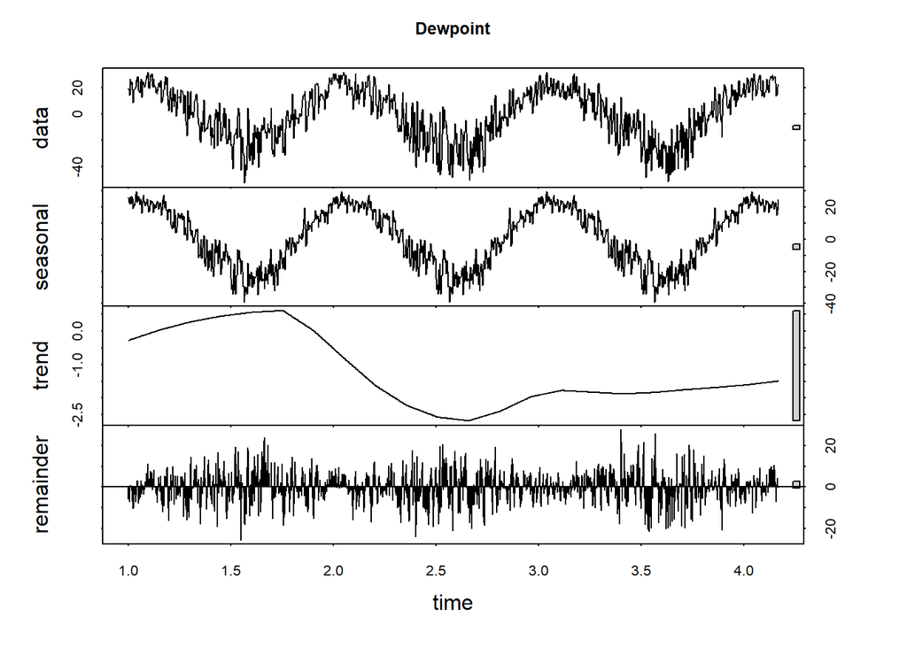

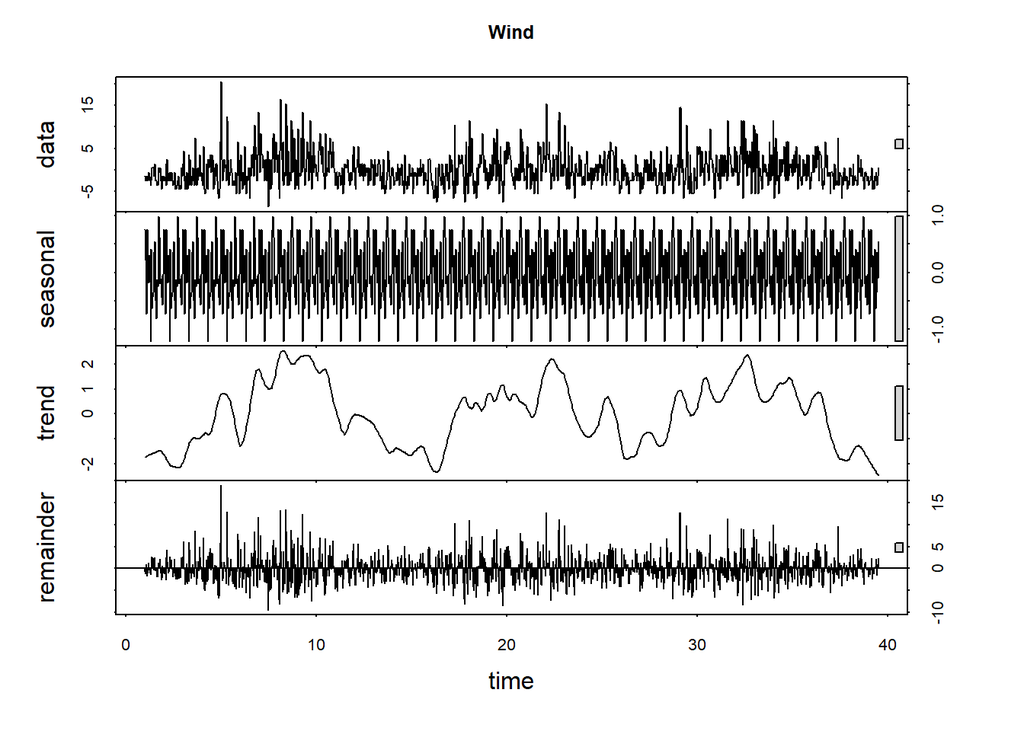

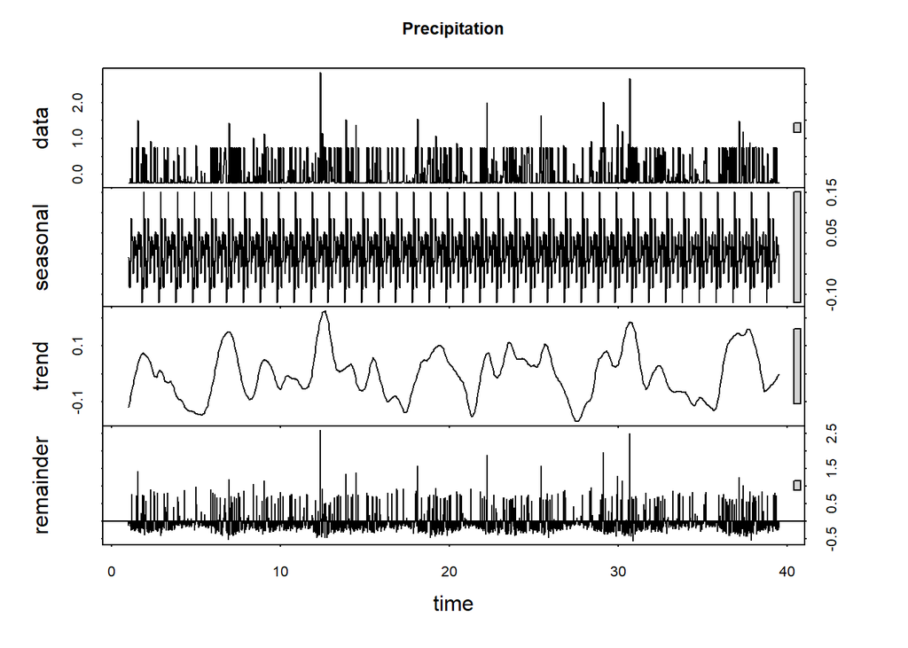

The above plots show a decomposed version of each time series by using loess. Temperature and Dewpoint are considered on a yearly basis whereas humidity, wind and precipitation are considered on a monthly basis.

## Interpretting ACF and PACF

## Humidity

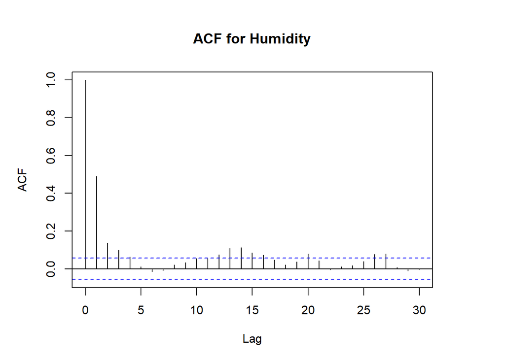

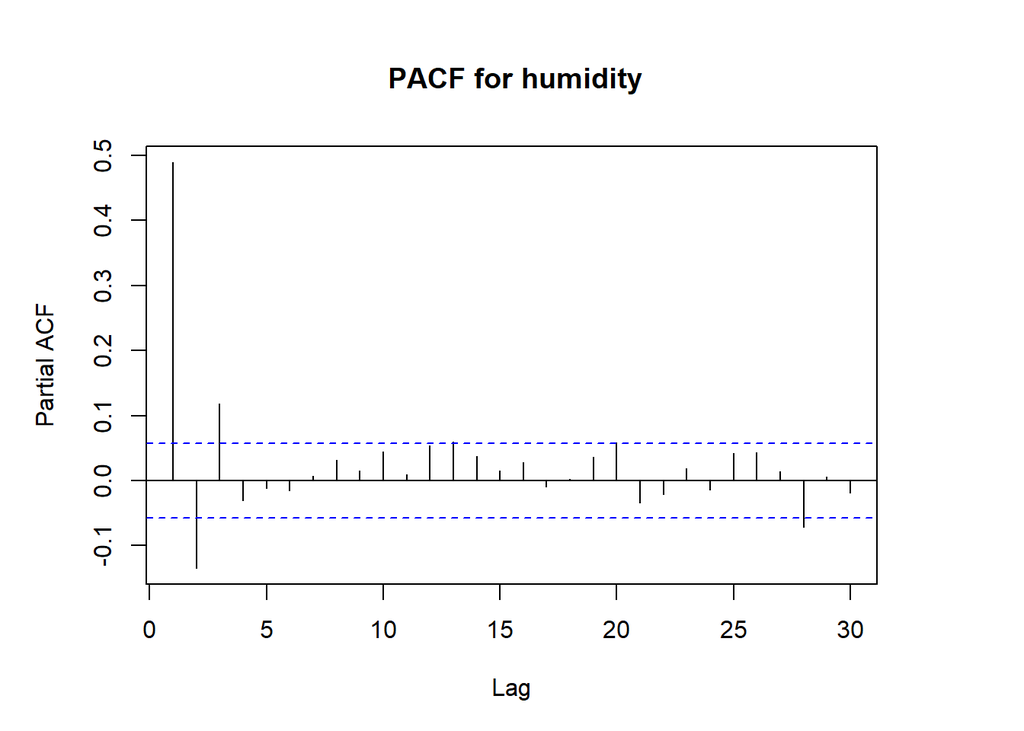

We can see that the lags in AutoCorrelation and Partial Autocorrelation plots die off after a certain number of significant lags so we can assume stationarity. To quantify stationarity we shall conduct the dickey-fuller test.

## Dewpoint

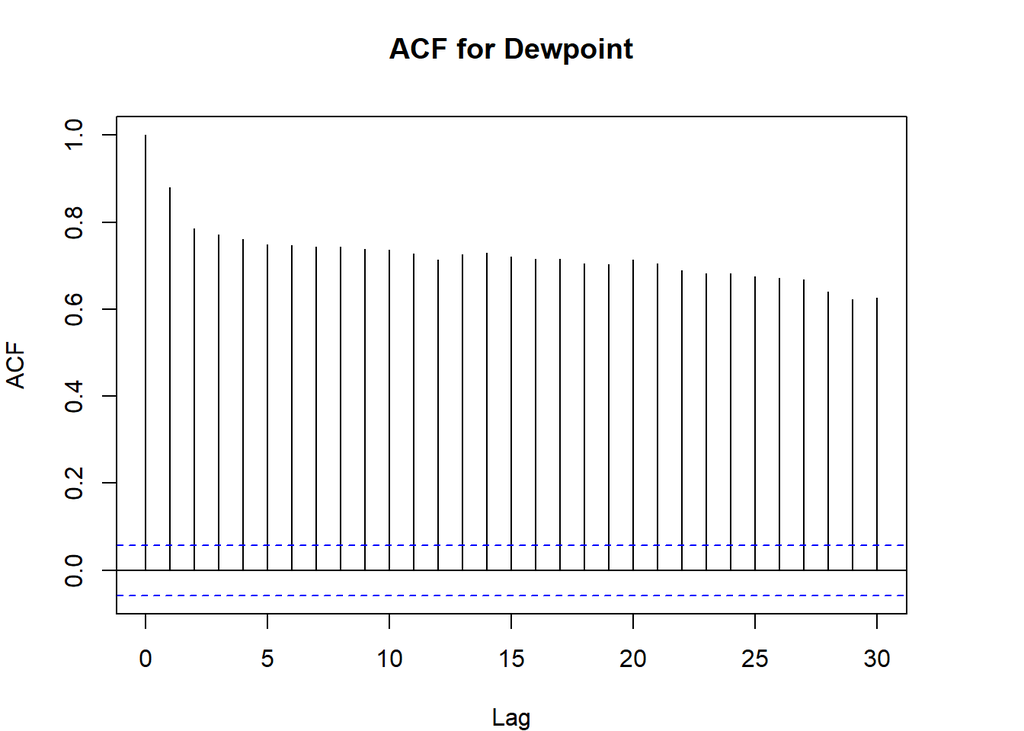

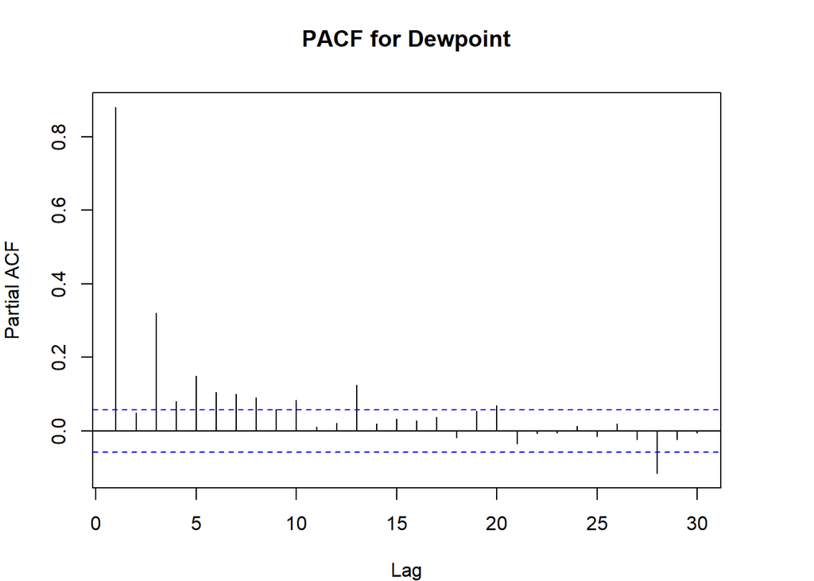

## Precipitation

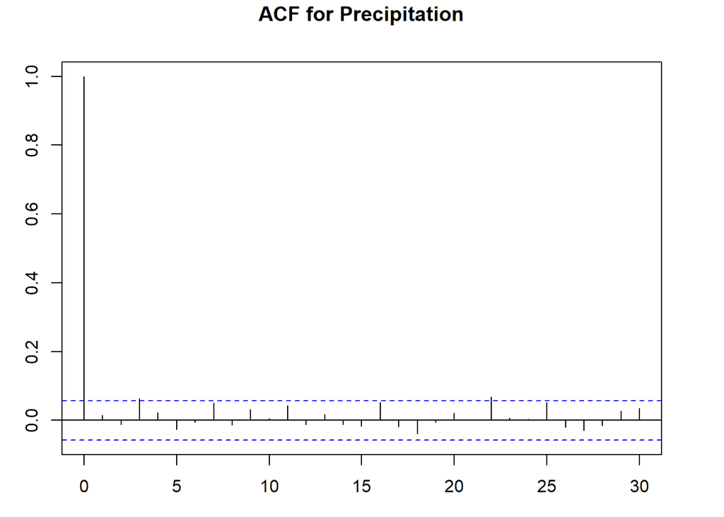

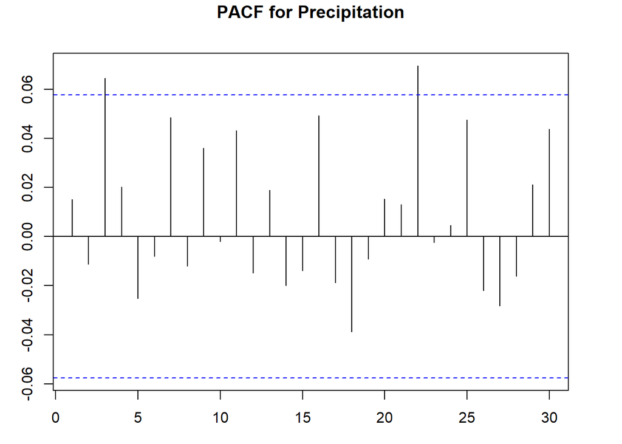

## Wind

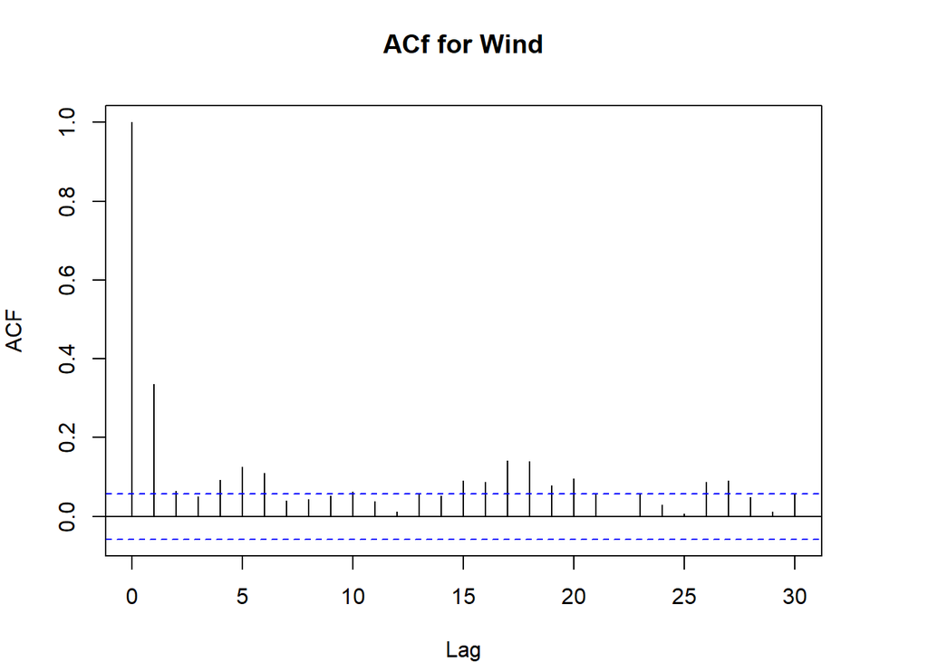

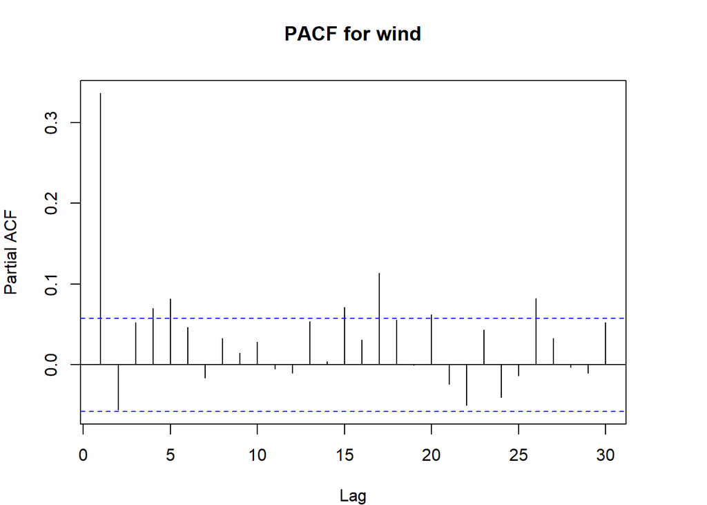

The ACf tells us that there is a significant correlation at lag 1. Also a seasonal lag of 5 might be present. The PACF does not present us with much information apart from the fact that some seasonal lag might exist.

## Temperature

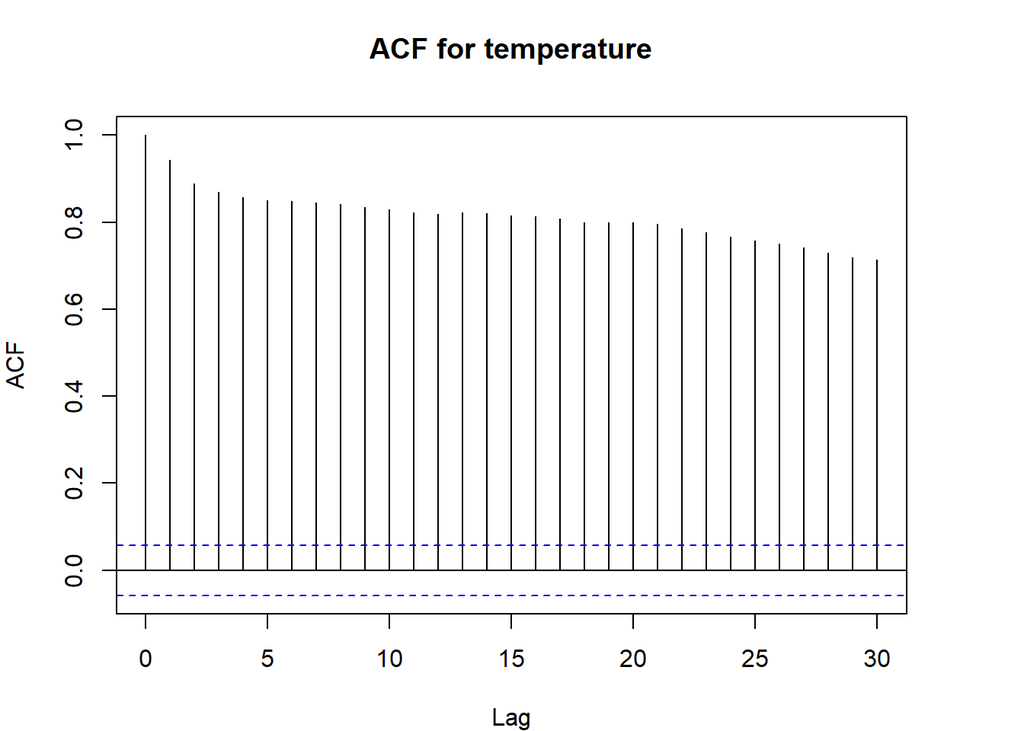

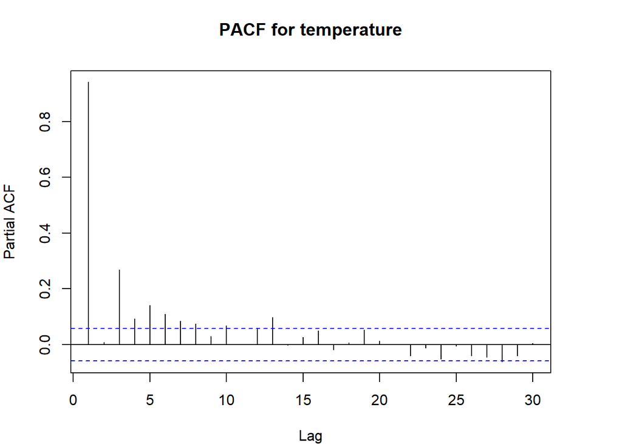

## Spectral Analysis

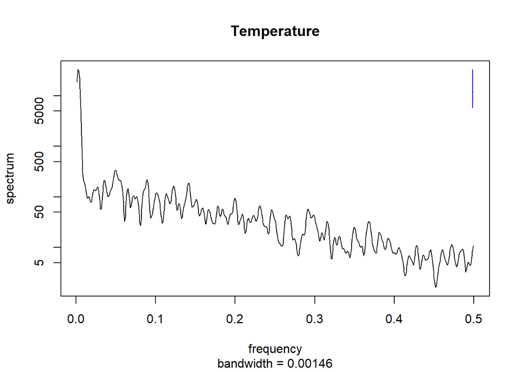

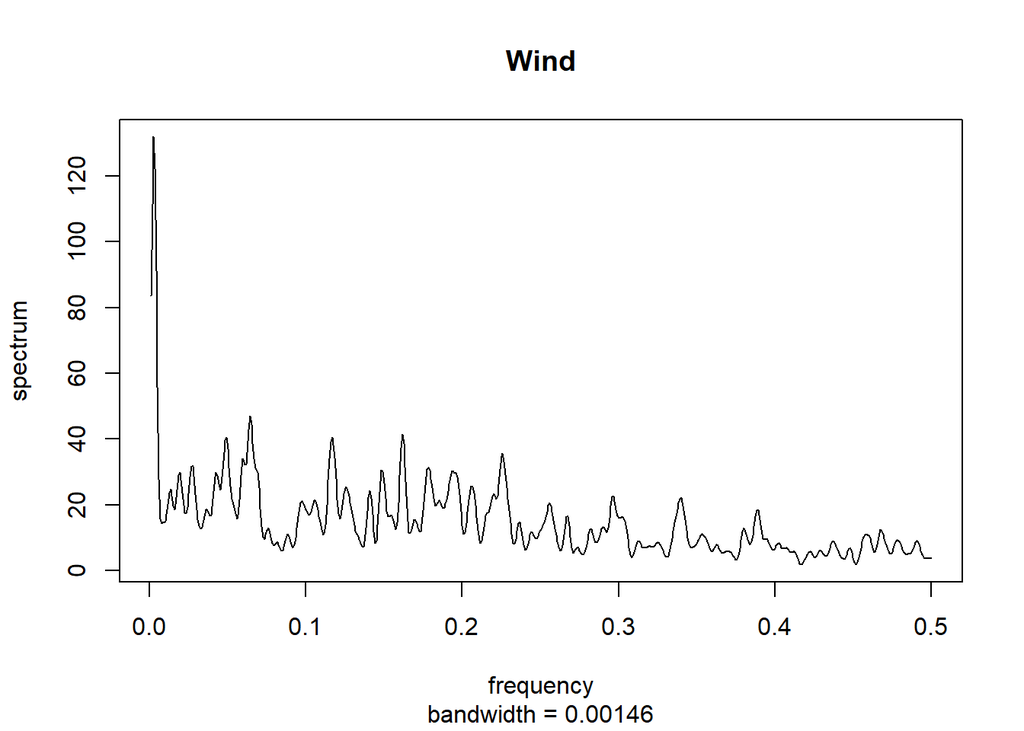

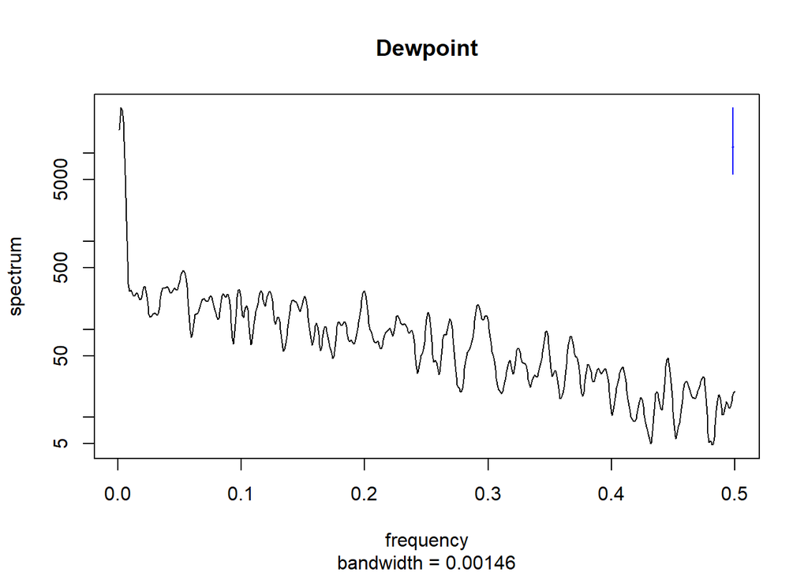

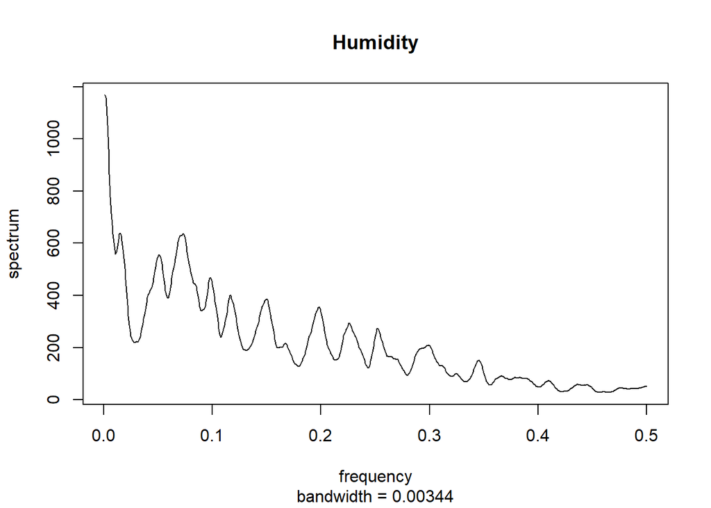

## Fitting Data

We noticed that there was seasonality in temperature and dewpoint We shall get rid of them by harmonic regression. A frequency of 3/N was taken. Temperature.

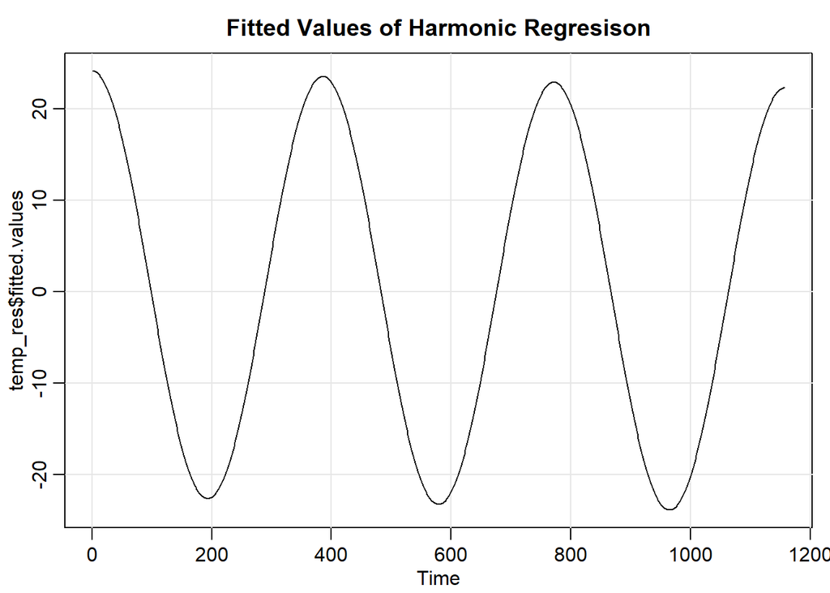

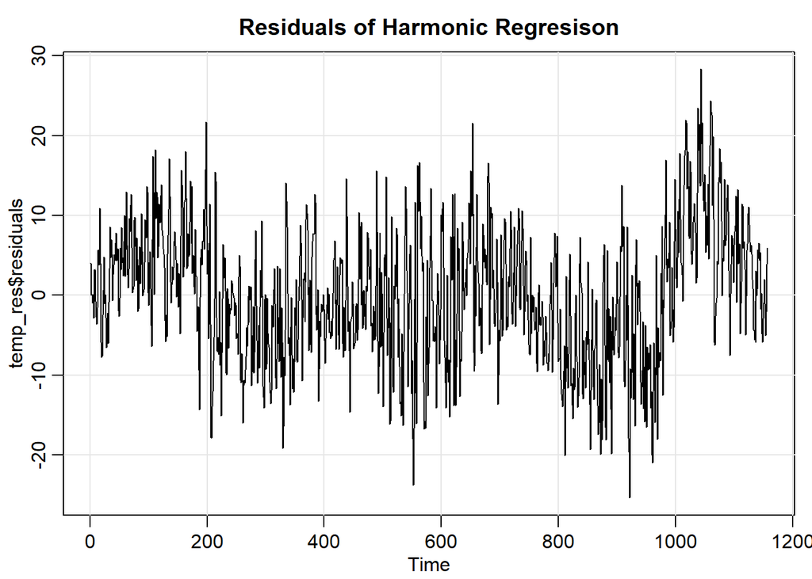

Dewpoint

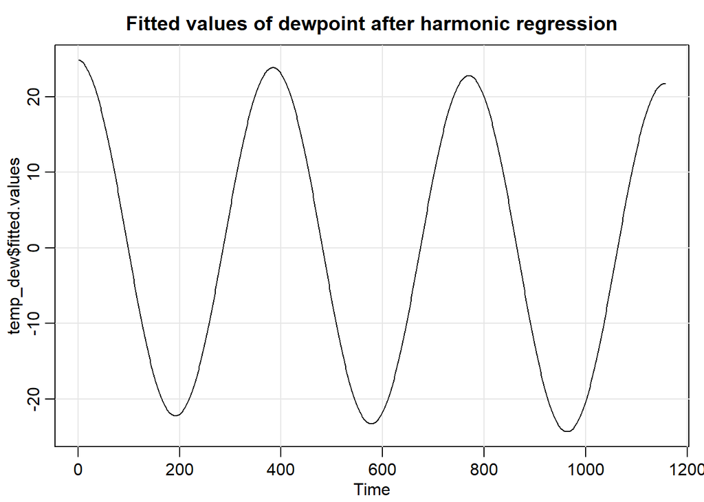

[figure not shown]

We shall work on the residuals of harmonic regression applied on temperature and dewpoint variables.

## Checking stationarity via Dickey - Fuller Test

Dickey- fuller test checks the null hypothesis whether unit roots of the characteristic equation is present. If the p-value of the test is below 0.05 we reject the null hypothesis in favor of the alternative saying that all the roots of the charactersitic equation are greater than 1 ie the roots lie outside the unit circle.

Humidity

```
##
##  Augmented Dickey-Fuller Test
##
## data:  weatherdata$humidity
## Dickey-Fuller = -8.8114, Lag order = 10, p-value = 0.01
## alternative hypothesis: stationary
```

Dew Point

```
##
##  Augmented Dickey-Fuller Test
##
## data:  temp_dew$residuals
## Dickey-Fuller = -7.032, Lag order = 10, p-value = 0.01
## alternative hypothesis: stationary
```

Wind

```
##
##  Augmented Dickey-Fuller Test
##
## data:  weatherdata$wind
## Dickey-Fuller = -8.2947, Lag order = 10, p-value = 0.01
## alternative hypothesis: stationary
```

Temperature

```
##
##  Augmented Dickey-Fuller Test
##
## data:  temp_res$residuals
## Dickey-Fuller = -5.9419, Lag order = 10, p-value = 0.01
## alternative hypothesis: stationary
```

All of the p-values are significant and hence we conclude that all of our time series are stationary.

## Cross Correlation Plots

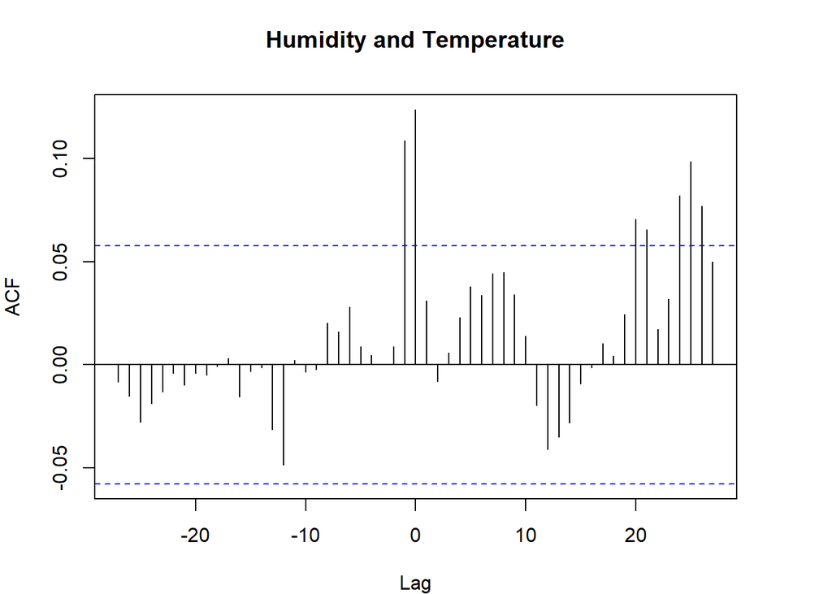

Humidity lags temperature. Thus humidity can be used as a predictor for temperature.

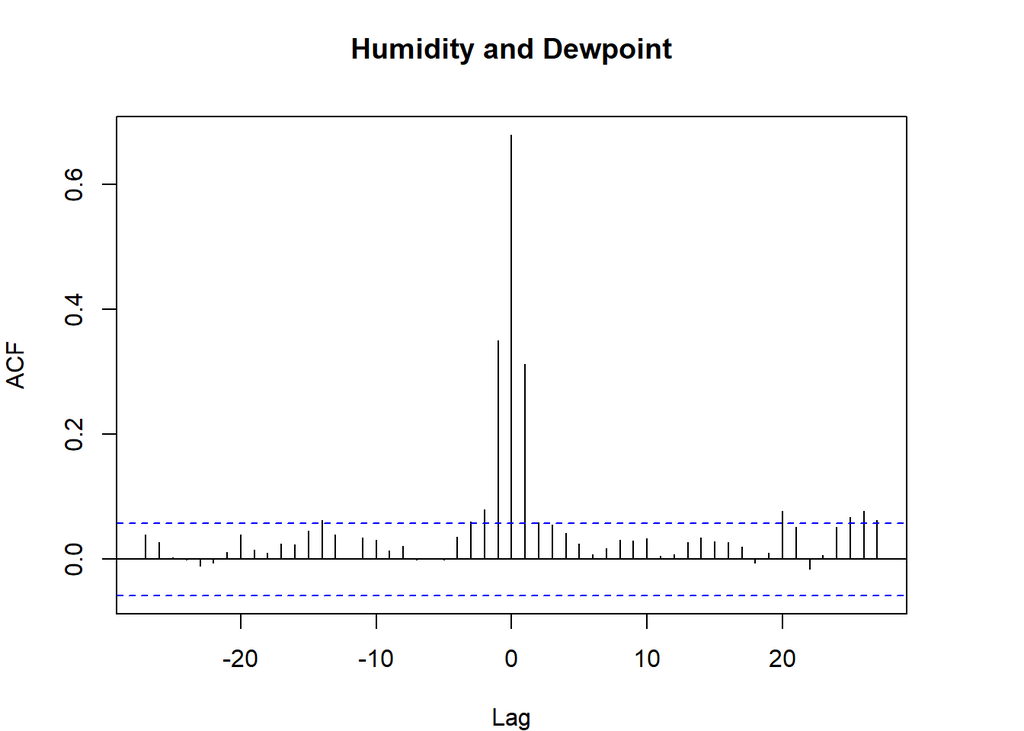

Humidity slightly leads dewpoint. Dewpoint might be a useful predictor for Humidity.

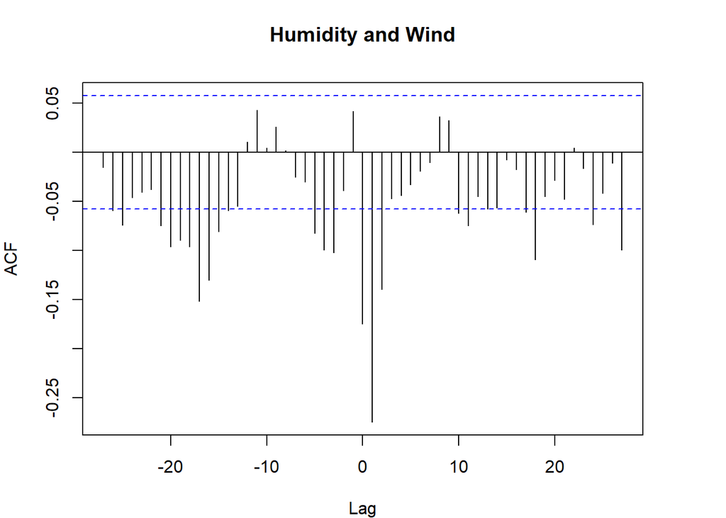

Humidity slightly leads wind. Wind might be a useful predictor for humidity.

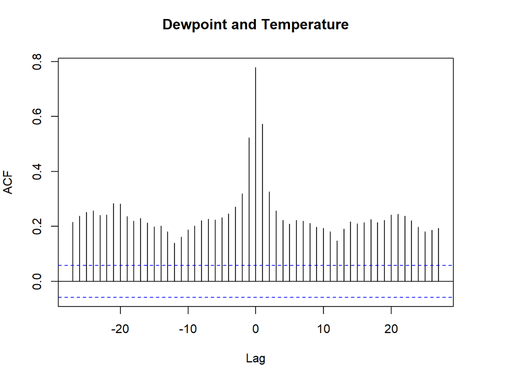

There is no strict lag/lead relationship that we can infer from this plot. We can just say that both the variables cause each other just like a cycle.

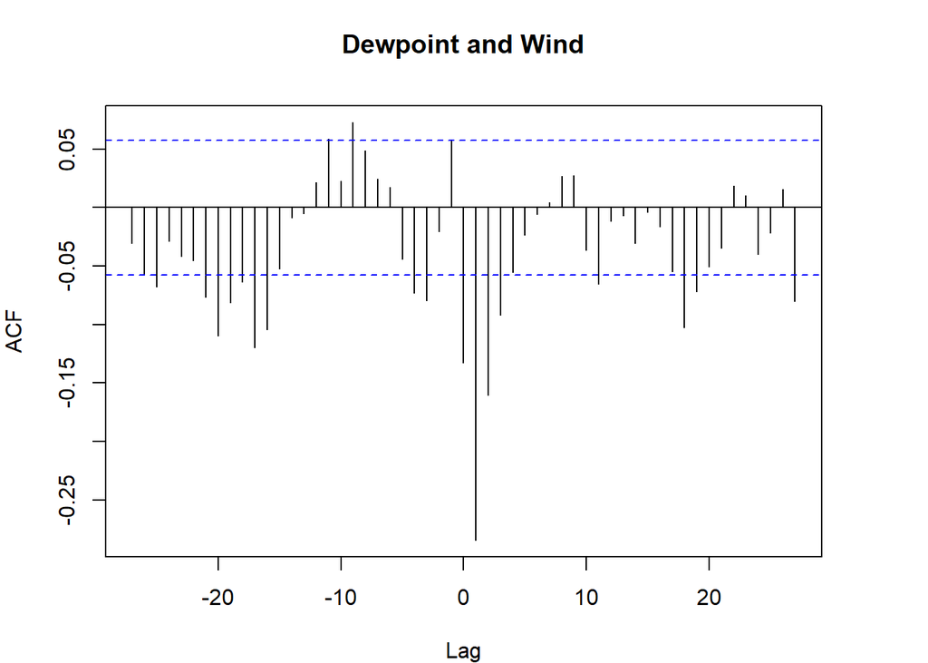

Dewpoint lags wind at lag 1,2 and 3. Dewpoint might be a useful predictor for wind.

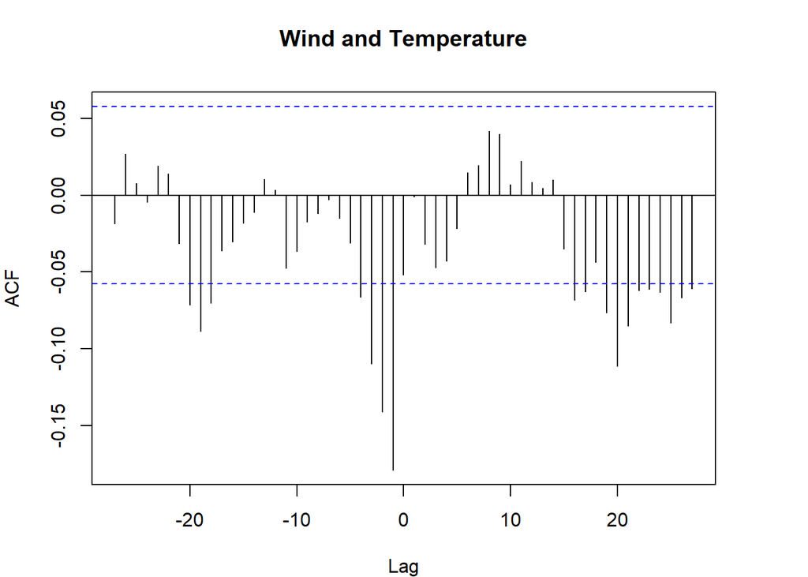

Now all the time series are stationary

## Model Fitting

Going to fit an ARIMA model for each of them to see how it performs.

Temperature

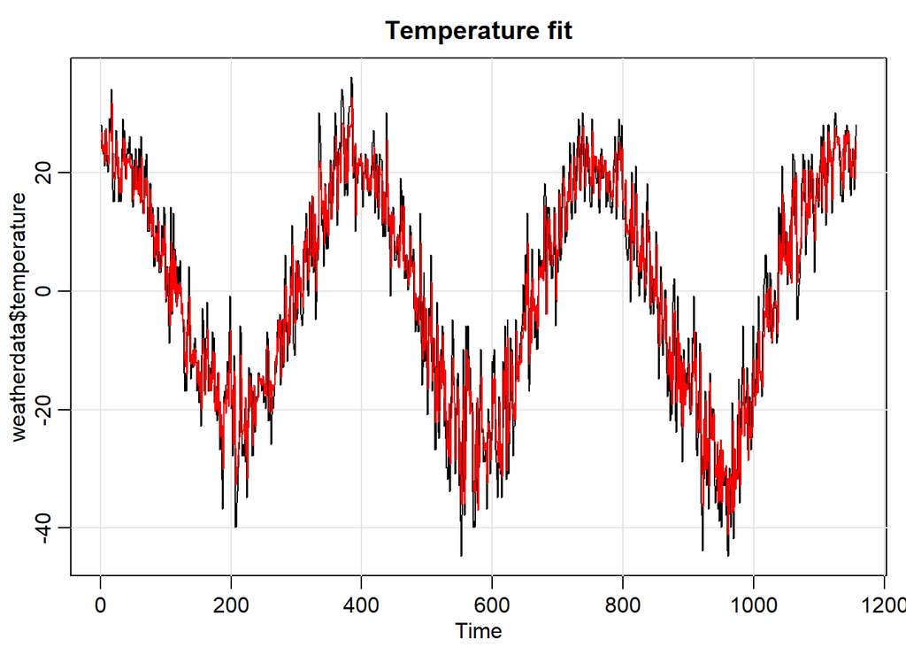

```
## Series: temp_res$residuals
## ARIMA(2,0,2)(1,0,0)[12] with non-zero mean
##
## Coefficients:
##          ar1      ar2      ma1      ma2     sar1    mean
##       1.3198  -0.3270  -0.5354  -0.3706  -0.0881  0.0170
## s.e.  0.0490   0.0479   0.0474   0.0396   0.0297  1.8065
##
## sigma^2 estimated as 29.57:  log likelihood=-3598.72
## AIC=7211.45   AICc=7211.55   BIC=7246.82
```

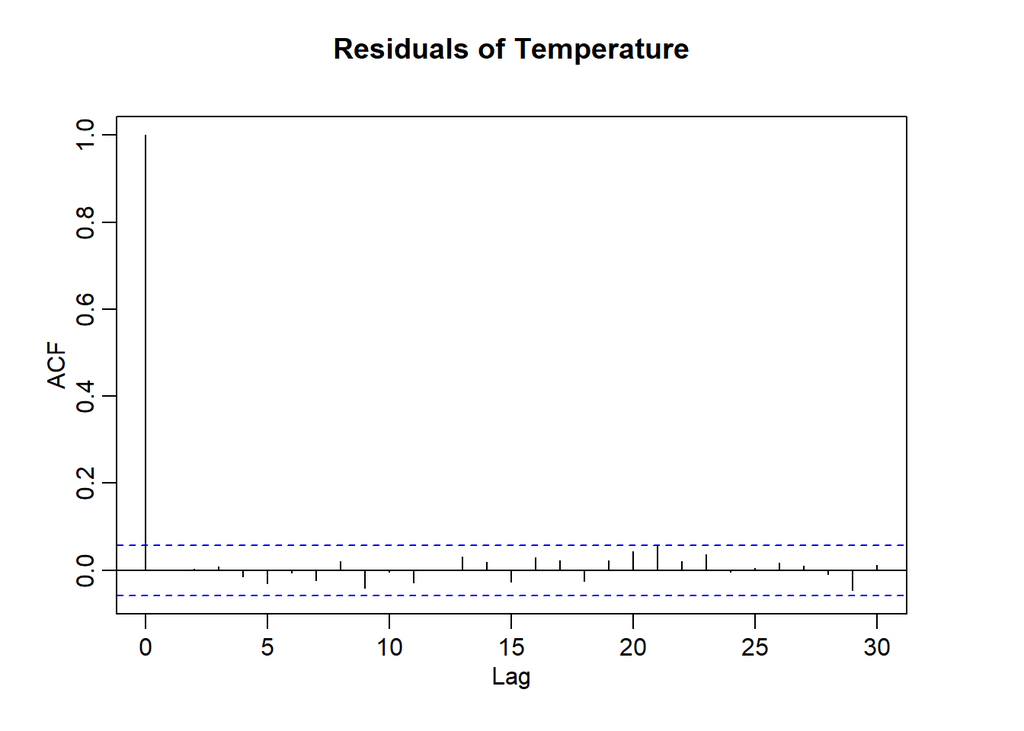

Dewpoint

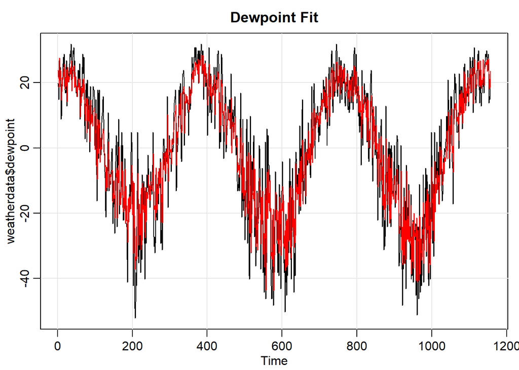

```
## Series: temp_dew$residuals
## ARIMA(2,0,2)(1,0,0)[12] with non-zero mean
##
## Coefficients:
##          ar1      ar2      ma1      ma2     sar1    mean
##       1.1275  -0.1391  -0.4609  -0.4481  -0.1005  0.0563
## s.e.  0.0560   0.0541   0.0508   0.0423   0.0296  1.6372
##
## sigma^2 estimated as 67.06:  log likelihood=-4072.15
## AIC=8158.29   AICc=8158.39   BIC=8193.67
```

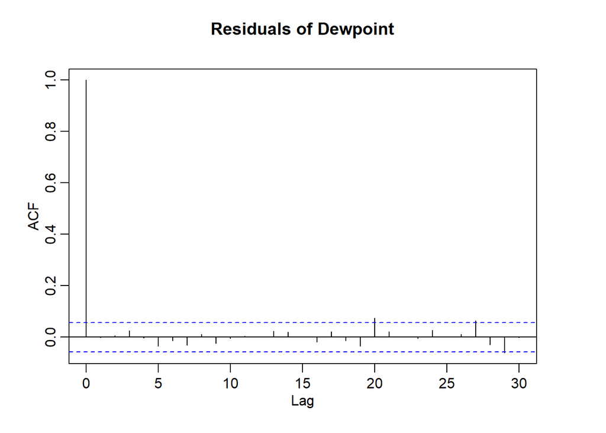

Humidity

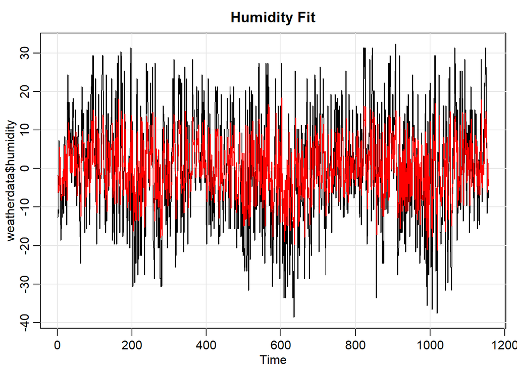

```
## Series: weatherdata$humidity
## ARIMA(1,0,2) with non-zero mean
##
## Coefficients:
##          ar1      ma1      ma2   mean
##       0.6392  -0.0633  -0.2401  0.002
## s.e.  0.1529   0.1613   0.0971  0.701
##
## sigma^2 estimated as 153.3:  log likelihood=-4551.07
## AIC=9112.14   AICc=9112.19   BIC=9137.41
```

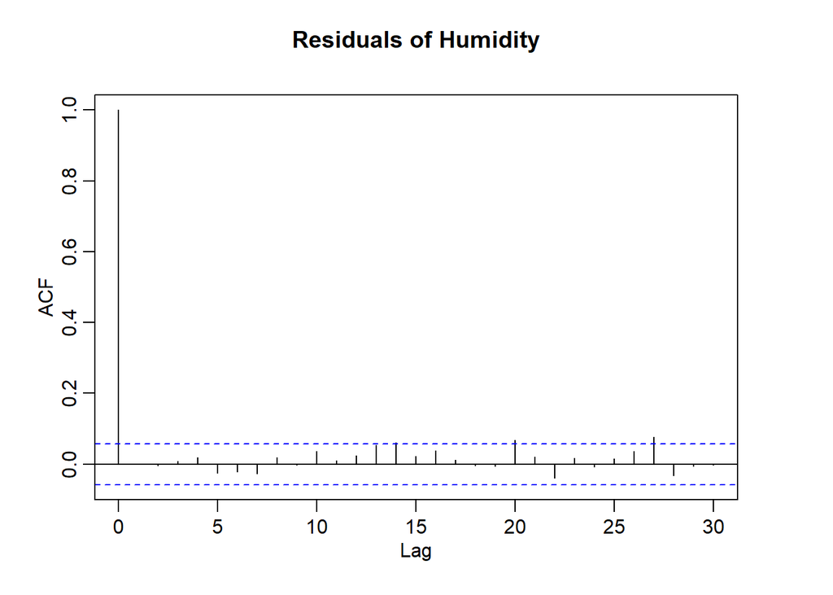

Wind

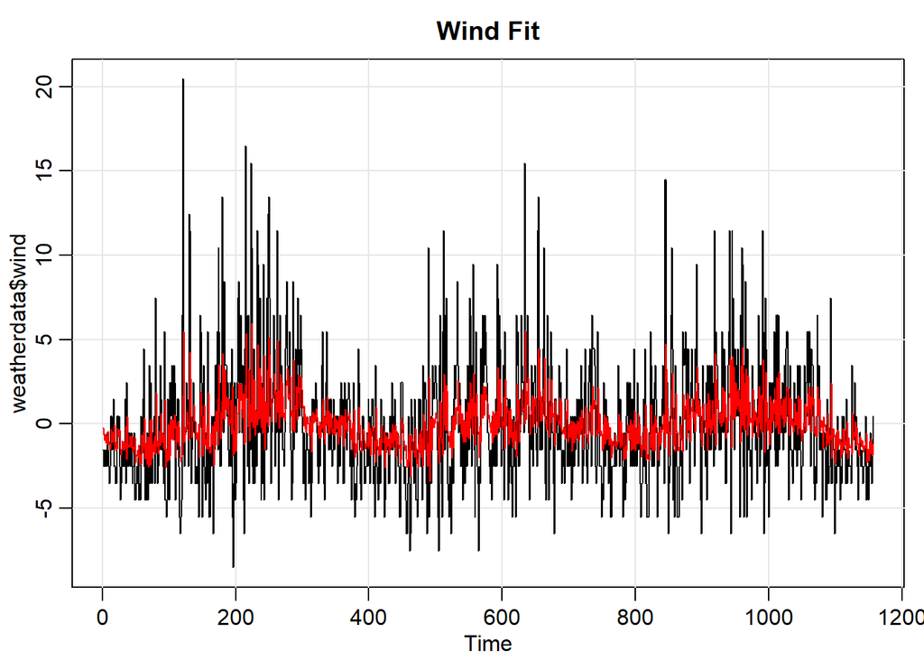

```
## Series: weatherdata$wind
## ARIMA(1,0,2) with non-zero mean
##
## Coefficients:
##          ar1      ma1      ma2     mean
##       0.9875  -0.6552  -0.2918  -0.1536
## s.e.  0.0074   0.0289   0.0278   0.4272
##
## sigma^2 estimated as 12.17:  log likelihood=-3085.55
## AIC=6181.1   AICc=6181.15   BIC=6206.37
```

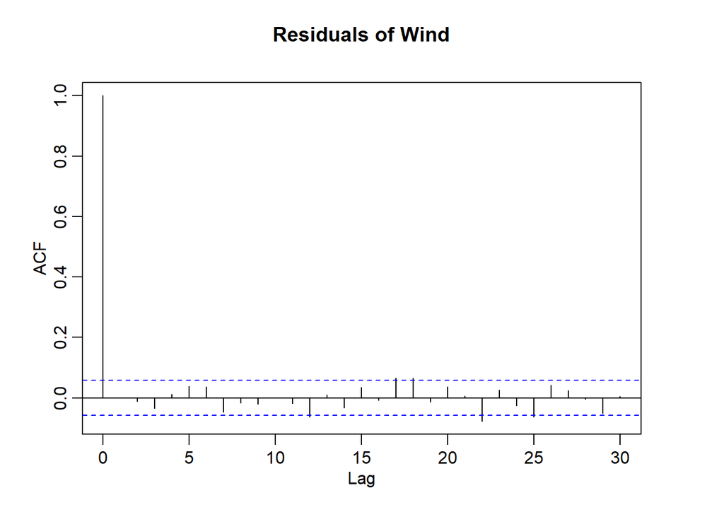

Conclusion : Temperature and Dewpoint models presented a good fit. Whereas humidity model fit was underfit and the wind model fit was overshot.

## VAR Modelling

```
## $selection
## AIC(n)  HQ(n)  SC(n) FPE(n)
##      5      3      1      5
##
## $criteria
##                   1            2            3            4            5
## AIC(n)     12.42480     12.38466     12.31318     12.31383     12.31202
## HQ(n)      12.45801     12.44444     12.39953     12.42675     12.45151
## SC(n)      12.51277     12.54300     12.54189     12.61292     12.68148
## FPE(n) 248899.18999 239105.08716 222611.76482 222758.35955 222356.89257
##                   6            7            8            9           10
## AIC(n)     12.31834     12.32396     12.32119     12.32735     12.32740
## HQ(n)      12.48439     12.51658     12.54038     12.57311     12.59973
## SC(n)      12.75818     12.83417     12.90177     12.97831     13.04873
## FPE(n) 223769.31066 225033.89236 224414.85714 225808.22658 225826.77013
```

Model Parameters

```
##
## VAR Estimation Results:
## =========================
## Endogenous variables: temperature, dewpoint, humidity, wind
## Deterministic variables: const
## Sample size: 1152
## Log Likelihood: -13543.405
## Roots of the characteristic polynomial:
## 0.9815 0.6823 0.6823 0.6326 0.5762 0.5762 0.5641 0.5641 0.5521 0.5521  0.55  0.55 0.5254 0.5254 0.4913 0.4766 0.4766 0.4535 0.4535 0.223
## Call:
## VAR(y = weatherdata[, c(2:5)], p = 5, type = "const")
##
##
## Estimation results for equation temperature:
## ============================================
## temperature = temperature.l1 + dewpoint.l1 + humidity.l1 + wind.l1 + temperature.l2 + dewpoint.l2 + humidity.l2 + wind.l2 + temperature.l3 + dewpoint.l3 + humidity.l3 + wind.l3 + temperature.l4 + dewpoint.l4 + humidity.l4 + wind.l4 + temperature.l5 + dewpoint.l5 + humidity.l5 + wind.l5 + const
##
##                 Estimate Std. Error t value Pr(>|t|)
## temperature.l1  0.950434   0.081971  11.595  < 2e-16 ***
## dewpoint.l1    -0.063090   0.083735  -0.753   0.4513
## humidity.l1     0.050285   0.039829   1.263   0.2070
## wind.l1        -0.322201   0.049420  -6.520 1.06e-10 ***
## temperature.l2 -0.173230   0.086987  -1.991   0.0467 *
## dewpoint.l2    -0.084030   0.084131  -0.999   0.3181
## humidity.l2    -0.016316   0.040417  -0.404   0.6865
## wind.l2         0.108593   0.053274   2.038   0.0417 *
## temperature.l3  0.185441   0.087382   2.122   0.0340 *
## dewpoint.l3     0.032004   0.083919   0.381   0.7030
## humidity.l3     0.012803   0.040310   0.318   0.7508
## wind.l3        -0.133904   0.053480  -2.504   0.0124 *
## temperature.l4  0.044818   0.086781   0.516   0.6056
## dewpoint.l4    -0.089656   0.083745  -1.071   0.2846
## humidity.l4     0.029153   0.039905   0.731   0.4652
## wind.l4         0.074136   0.053447   1.387   0.1657
## temperature.l5  0.141342   0.082817   1.707   0.0882 .
## dewpoint.l5     0.001135   0.083404   0.014   0.9891
## humidity.l5    -0.002411   0.038743  -0.062   0.9504
## wind.l5         0.032844   0.050512   0.650   0.5157
## const          -0.000363   0.165251  -0.002   0.9982
## ---
```

[output cut: 112 more lines]

```
##
##
## Covariance matrix of residuals:
##             temperature dewpoint humidity   wind
## temperature      31.456   31.739    6.683 -0.734
## dewpoint         31.739   64.901   71.527 -4.043
## humidity          6.683   71.527  146.585 -6.967
## wind             -0.734   -4.043   -6.967 11.725
##
## Correlation matrix of residuals:
##             temperature dewpoint humidity     wind
## temperature     1.00000   0.7025  0.09842 -0.03822
## dewpoint        0.70246   1.0000  0.73333 -0.14656
## humidity        0.09842   0.7333  1.00000 -0.16805
## wind           -0.03822  -0.1466 -0.16805  1.00000
```

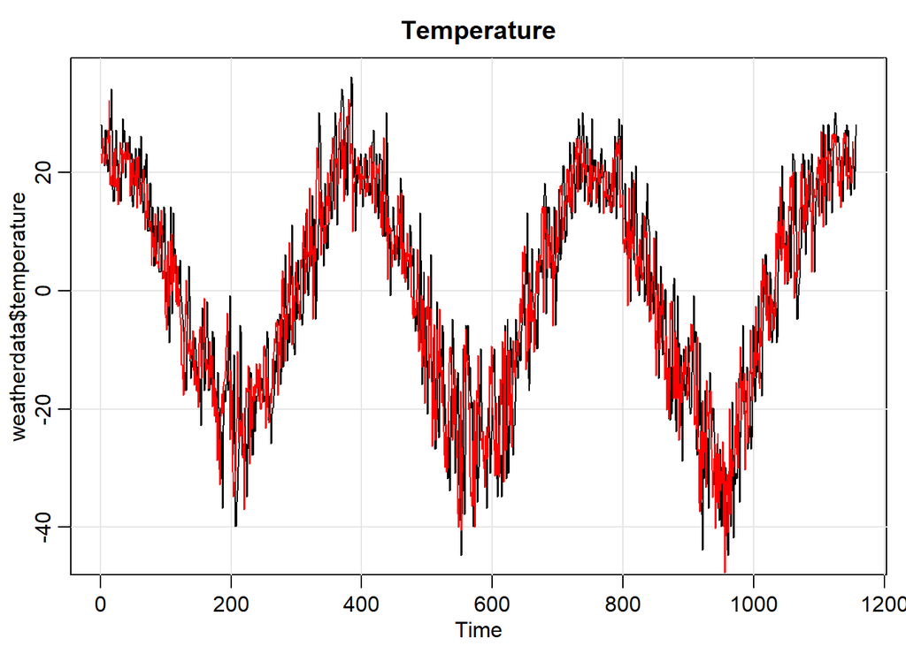

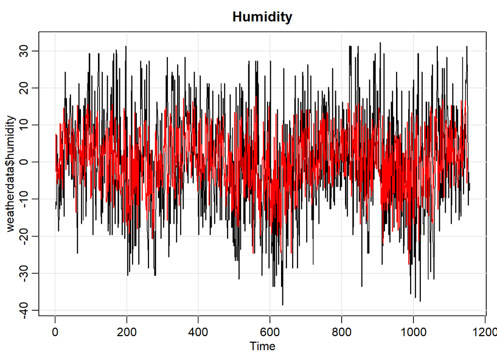

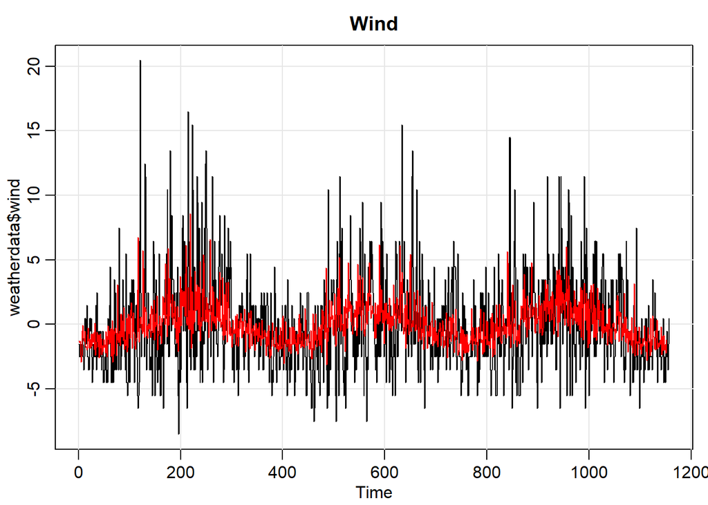

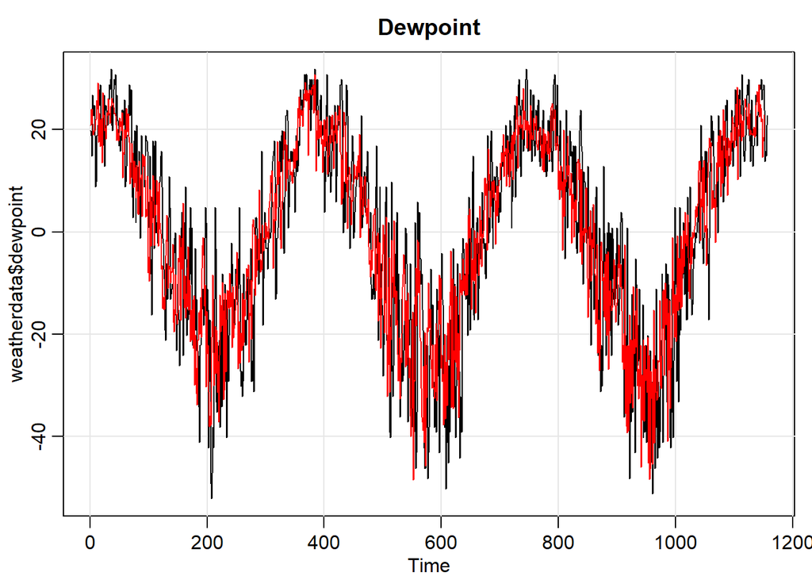

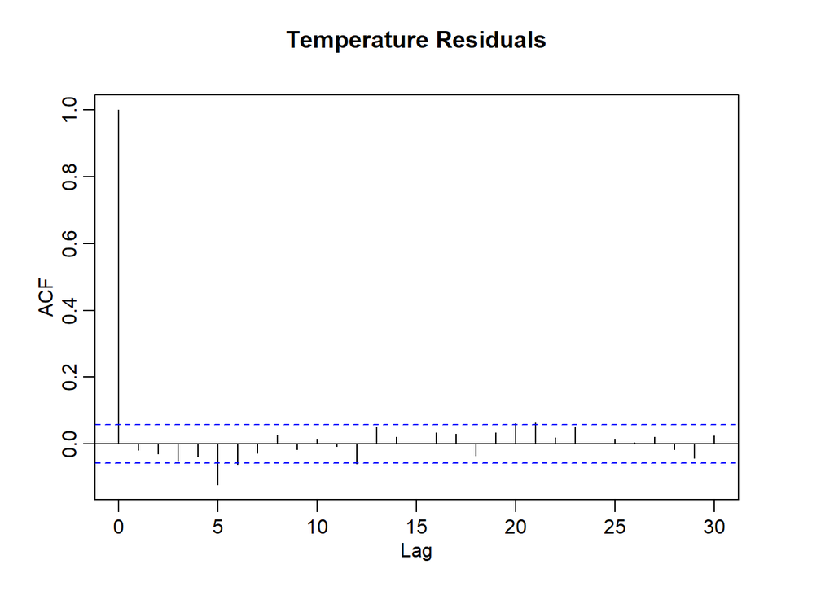

```
##
##  Box-Pierce test
##
## data:  resid(var_fit)[, 1]
## X-squared = 22.781, df = 5, p-value = 0.0003717
```

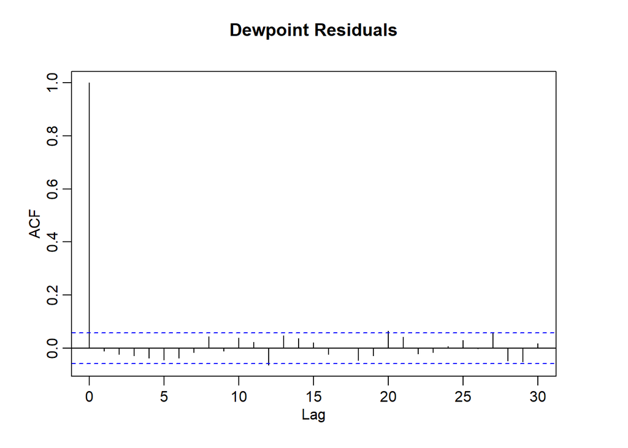

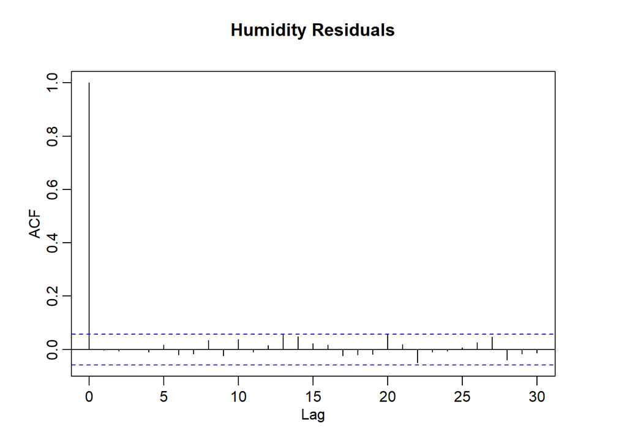

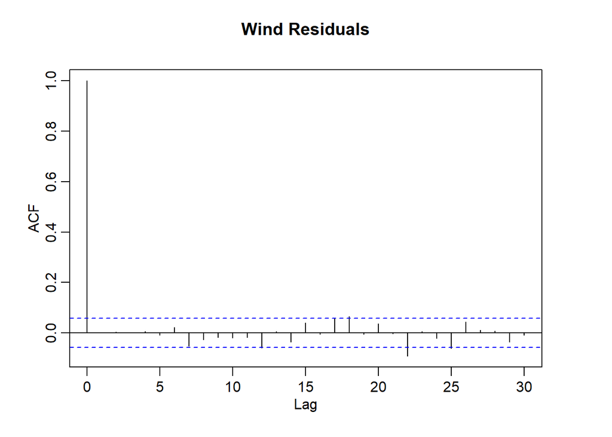

Granger - Causality

```
##
##  Granger causality H0: dewpoint do not Granger-cause temperature
##  humidity wind
##
## data:  VAR object var_fit
## F-Test = 1.6142, df1 = 15, df2 = 4524, p-value = 0.06204
```

Temperature has an effect on dewpoint,humidity and wind.

Wind has an effect on temperature, dewpoint and humidity.

Humidity does not have a significant effect on temperature,dewpoint and wind.

Dewpoint(p-value : 0.06) may or may not have an effect on temperature,humidity and wind depending on the threshold.

CCF Results: Humidity might be used to predict wind and temperature.

Temperature can be predicted by Humidity.

Dewpoint might be a useful predictor for Humidity.

Dewpoint might be a good predictor for wind.

Dewpoint and temperature seem to have a cycle effect.

Temperature might be a useful predictor for wind.

## Extra: Forecasting using STL

Using STL Decompostion. Fit ARIMA model on residuals.

Temperature: Using STL Decomposition + ARIMA on the residuals. Frequency is set to 365 as seasons occur on a yearly basis.

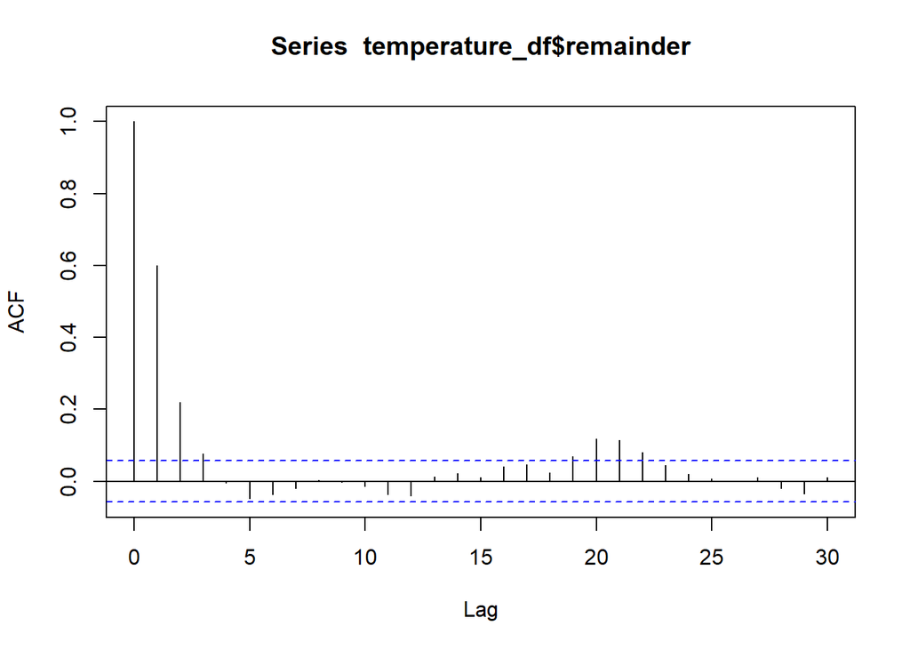

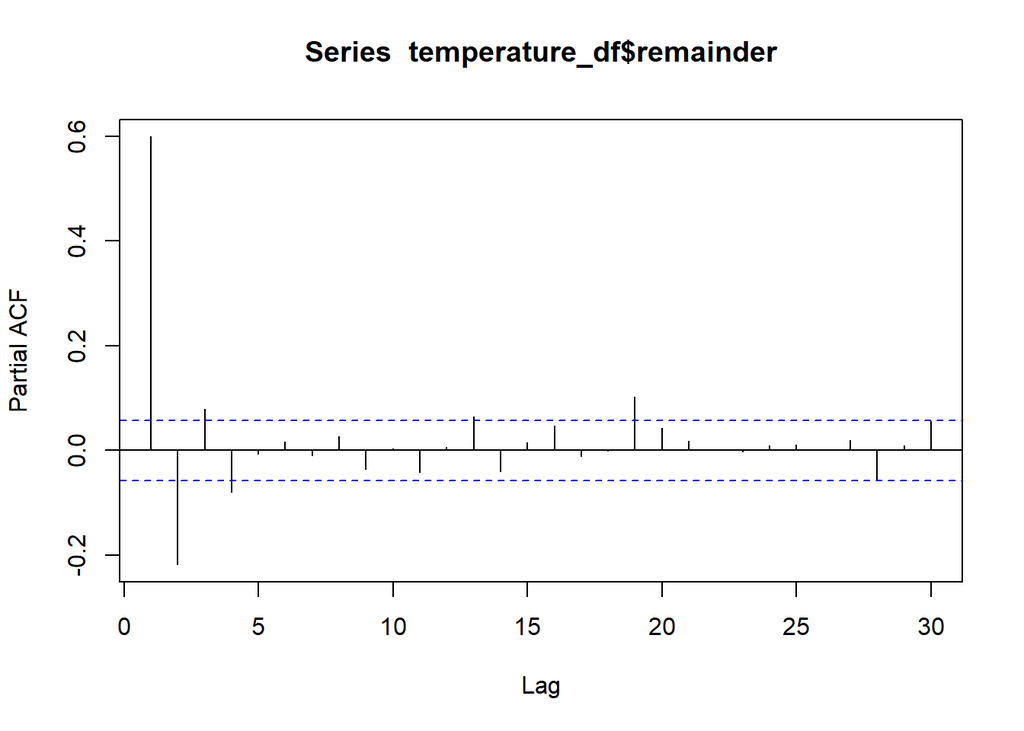

```
## [1] 6709.943
```

```
## [1] 6730.158
```

```
## Series: temperature_df$remainder
## ARIMA(1,0,1) with non-zero mean
##
## Coefficients:
##          ar1     ma1    mean
##       0.3597  0.3948  0.0022
## s.e.  0.0414  0.0408  0.2803
##
## sigma^2 estimated as 19.24:  log likelihood=-3350.97
## AIC=6709.94   AICc=6709.98   BIC=6730.16
```

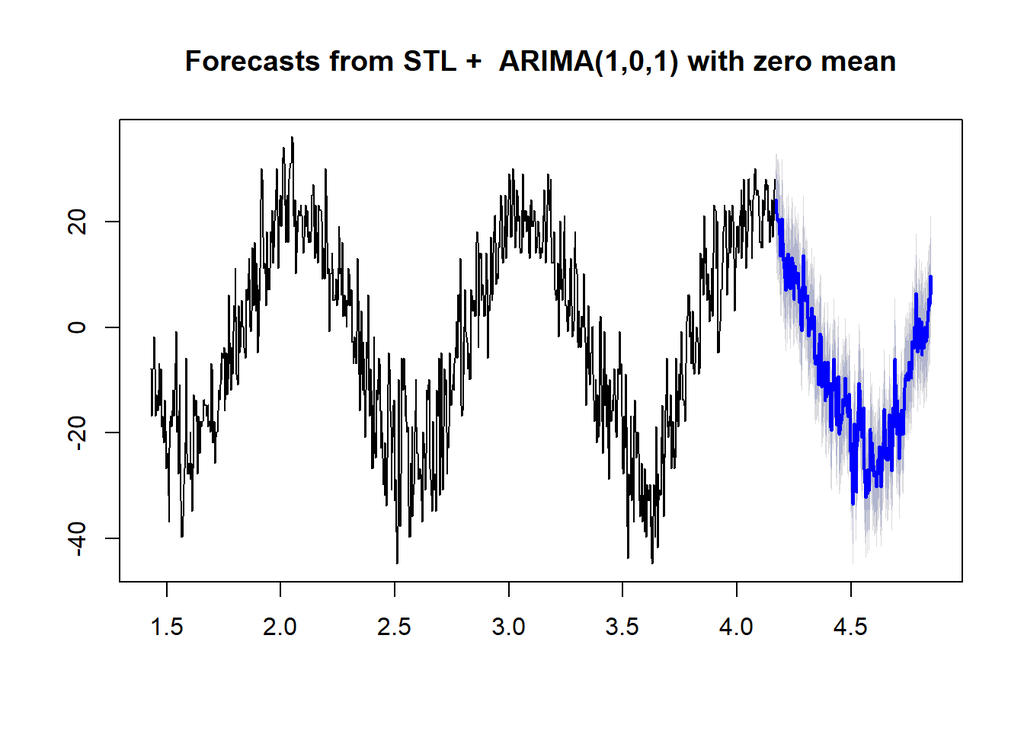

Humidity:

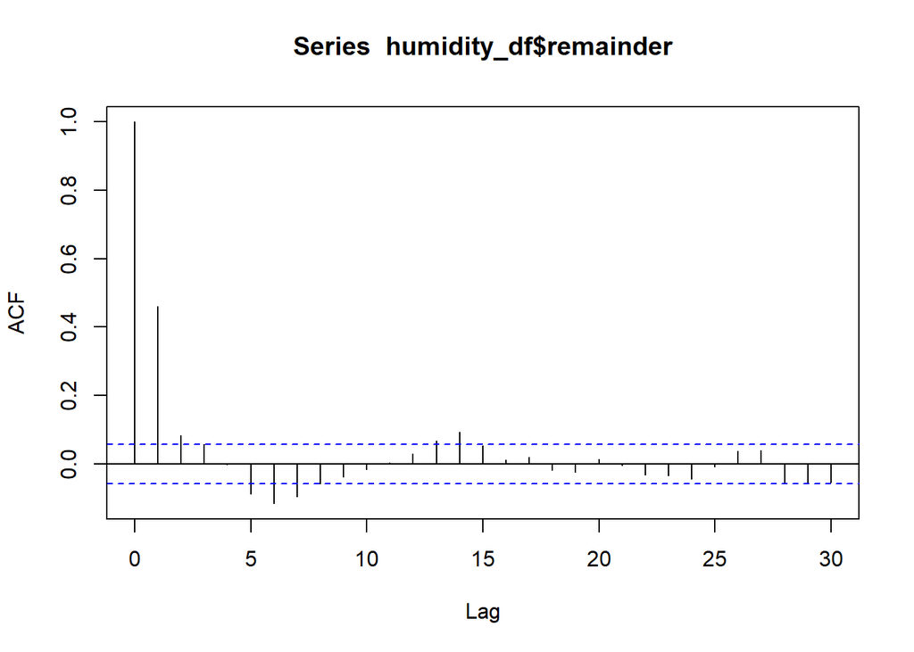

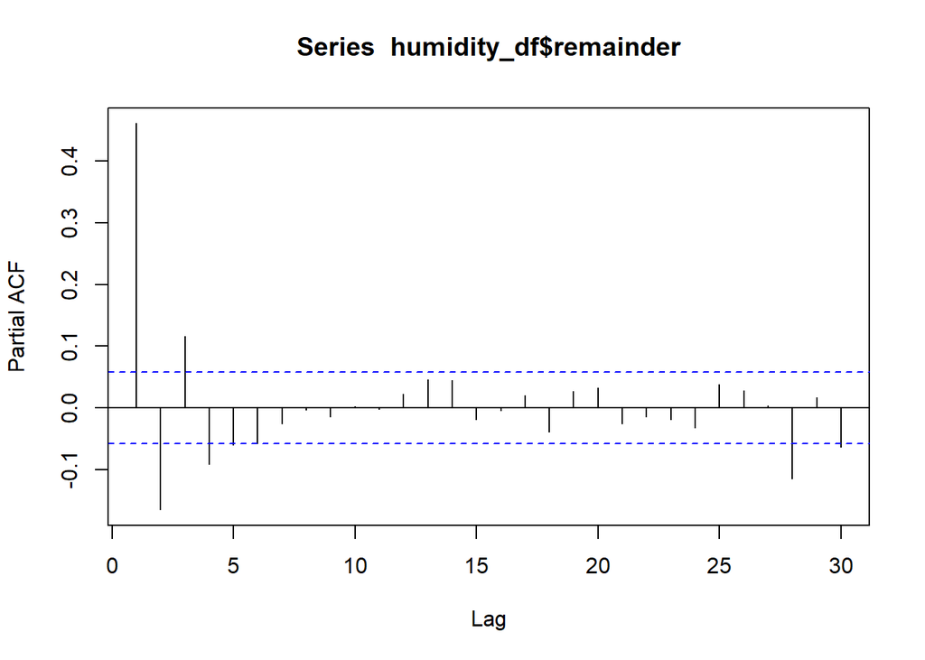

```
## [1] 8688.248
```

```
## [1] 8708.463
```

```
## Series: humidity_df$remainder
## ARIMA(1,0,1) with non-zero mean
##
## Coefficients:
##          ar1     ma1    mean
##       0.1113  0.4570  0.0078
## s.e.  0.0552  0.0498  0.4962
##
## sigma^2 estimated as 106.4:  log likelihood=-4340.12
## AIC=8688.25   AICc=8688.28   BIC=8708.46
```

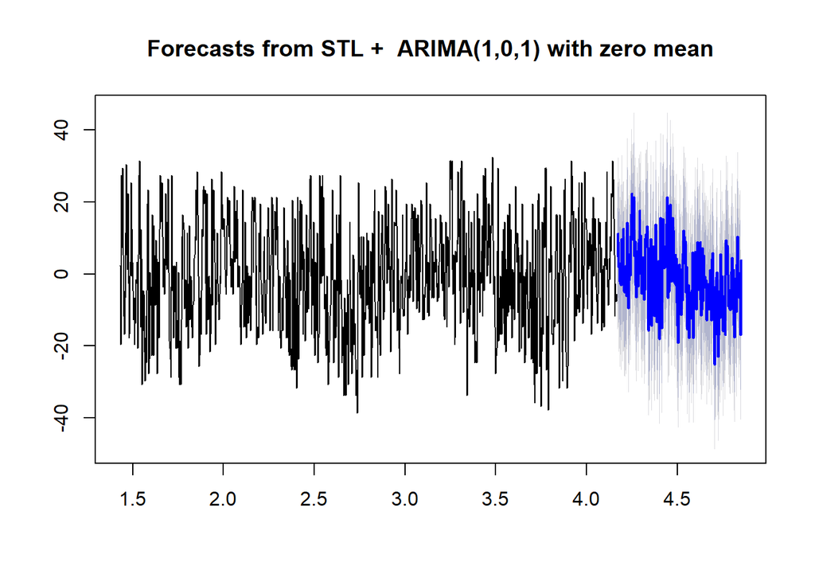

Dewpoint

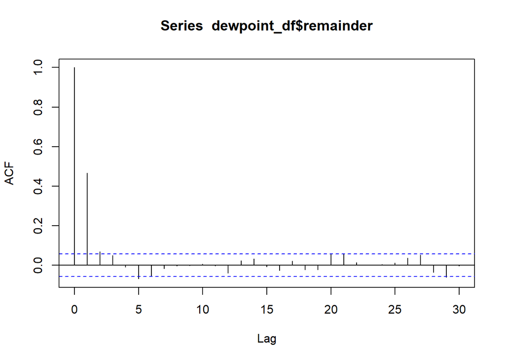

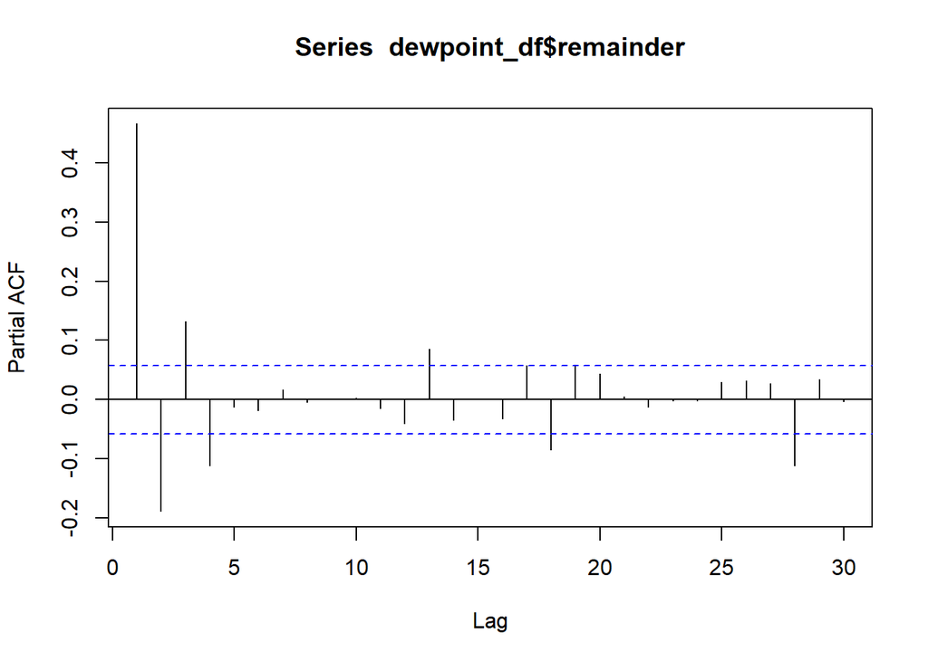

[output not shown]